# Coursera Regression Models

Timo Grossenbacher, Data Journalist in Chief, “Bleifuss Magazine”

September 21, 2015

## Summary

What’s up, friends of gasoline stench and burning tires? So today we took the effort to finally provide you with the answers you’ve been waiting for all your life:

- Is an automatic or manual transmission better for MPG? At first sight, yes. In our dataset, manual cars tend to make more miles per gallon. At second sight, though, it turns out that this is actually due to weight - manual cars are generally a lot lighter than automatic cars. And weight greatly affects miles per gallon, of course. So taking into account weight, the effect of transmission mode becomes insignificant.
- What difference does it actually make? Without weight considered, it makes a difference of around 7 miles per gallon. With weight considered, and that’s what we should take as the “truth”: Nothing at all. Although it’s probably best for the environment to drive a light car that has manual transmission. Right? Also more fun, too.

## Analysis

For the nerds among you (we know that true mechanics are actually car hackers…), the analysis in detail:

### Load the data

```
##       mpg             cyl             disp             hp
##  Min.   :10.40   Min.   :4.000   Min.   : 71.1   Min.   : 52.0
##  1st Qu.:15.43   1st Qu.:4.000   1st Qu.:120.8   1st Qu.: 96.5
##  Median :19.20   Median :6.000   Median :196.3   Median :123.0
##  Mean   :20.09   Mean   :6.188   Mean   :230.7   Mean   :146.7
##  3rd Qu.:22.80   3rd Qu.:8.000   3rd Qu.:326.0   3rd Qu.:180.0
##  Max.   :33.90   Max.   :8.000   Max.   :472.0   Max.   :335.0
##       drat             wt             qsec             vs
##  Min.   :2.760   Min.   :1.513   Min.   :14.50   Min.   :0.0000
##  1st Qu.:3.080   1st Qu.:2.581   1st Qu.:16.89   1st Qu.:0.0000
##  Median :3.695   Median :3.325   Median :17.71   Median :0.0000
##  Mean   :3.597   Mean   :3.217   Mean   :17.85   Mean   :0.4375
##  3rd Qu.:3.920   3rd Qu.:3.610   3rd Qu.:18.90   3rd Qu.:1.0000
##  Max.   :4.930   Max.   :5.424   Max.   :22.90   Max.   :1.0000
##        am              gear            carb
##  Min.   :0.0000   Min.   :3.000   Min.   :1.000
##  1st Qu.:0.0000   1st Qu.:3.000   1st Qu.:2.000
##  Median :0.0000   Median :4.000   Median :2.000
##  Mean   :0.4062   Mean   :3.688   Mean   :2.812
##  3rd Qu.:1.0000   3rd Qu.:4.000   3rd Qu.:4.000
##  Max.   :1.0000   Max.   :5.000   Max.   :8.000
```

### Exploratory Data Analysis

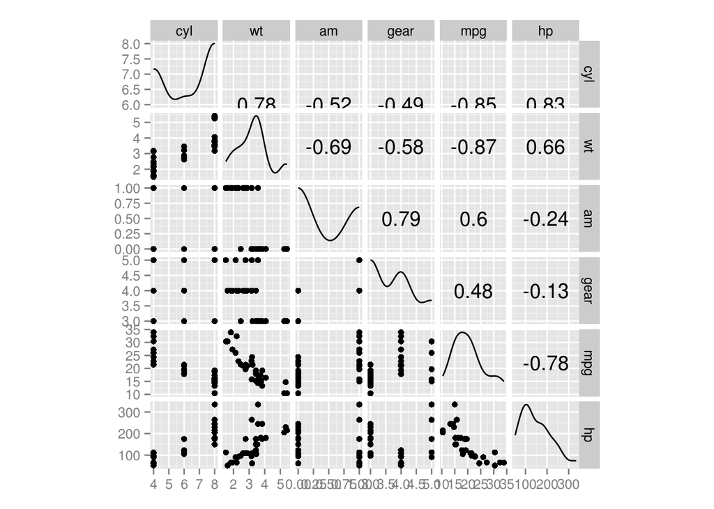

There seems to be a correlation between weight and mpg, for example, but also between transmission and mpg -> the stuff we’re interested in. So let’s explore this more deeply.

### Analysis

#### Simple

```r
# simple model, am as sole regressor
summary(lm(mpg ~ factor(am), data = mtcars_mod))
```

```
##
## Call:
## lm(formula = mpg ~ factor(am), data = mtcars_mod)
##
## Residuals:
##     Min      1Q  Median      3Q     Max
## -9.3923 -3.0923 -0.2974  3.2439  9.5077
##
## Coefficients:
##             Estimate Std. Error t value Pr(>|t|)
## (Intercept)   17.147      1.125  15.247 1.13e-15 ***
## factor(am)1    7.245      1.764   4.106 0.000285 ***
## ---
## Signif. codes:  0 '***' 0.001 '**' 0.01 '*' 0.05 '.' 0.1 ' ' 1
##
## Residual standard error: 4.902 on 30 degrees of freedom
## Multiple R-squared:  0.3598, Adjusted R-squared:  0.3385
## F-statistic: 16.86 on 1 and 30 DF,  p-value: 0.000285
```

Yes, looks like transmission mode makes a difference. Average MPG for automatic transmission is 17.15 mpg, that for manual transmission is roughly 24.4 mpg, thus it makes an average difference of 7.25 mpg, and this difference is significant on the 95%-confidence level.

BUT WAIT, transmission is also strongly correlated with weight - looks like automatic cars are generally heavier (which makes sense, most trucks, for example, are automatic). And weight is strongly negatively correlated with mpg, so it might be an important confounder. Let’s explore this.

```
##   cyl    wt am gear  mpg  hp wt_binary
## 1   6 2.620  1    4 21.0 110         0
## 2   6 2.875  1    4 21.0 110         0
## 3   4 2.320  1    4 22.8  93         0
## 4   6 3.215  0    3 21.4 110         0
## 5   8 3.440  0    3 18.7 175         1
## 6   6 3.460  0    3 18.1 105         1
```

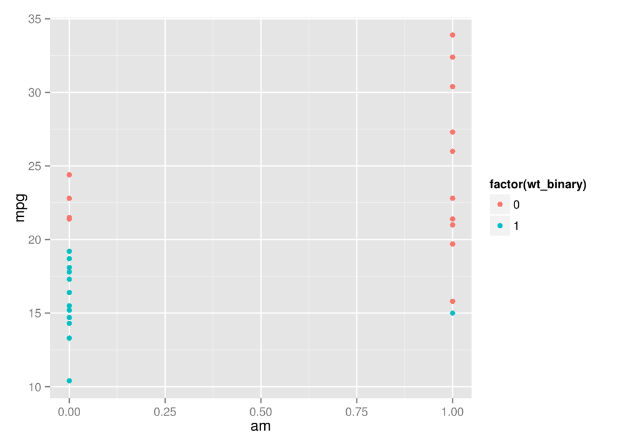

The plot reaffirms this. Most manual cars are indeed lighter (0). Let’s specify a model which considers both regressors.

```r
summary(lm(mpg ~ factor(am) + wt, data = mtcars_mod))
```

```
##
## Call:
## lm(formula = mpg ~ factor(am) + wt, data = mtcars_mod)
##
## Residuals:
##     Min      1Q  Median      3Q     Max
## -4.5295 -2.3619 -0.1317  1.4025  6.8782
##
## Coefficients:
##             Estimate Std. Error t value Pr(>|t|)
## (Intercept) 37.32155    3.05464  12.218 5.84e-13 ***
## factor(am)1 -0.02362    1.54565  -0.015    0.988
## wt          -5.35281    0.78824  -6.791 1.87e-07 ***
## ---
## Signif. codes:  0 '***' 0.001 '**' 0.01 '*' 0.05 '.' 0.1 ' ' 1
##
## Residual standard error: 3.098 on 29 degrees of freedom
## Multiple R-squared:  0.7528, Adjusted R-squared:  0.7358
## F-statistic: 44.17 on 2 and 29 DF,  p-value: 1.579e-09
```

Our fears are justified. When weight is considered too, the effect of transmission becomes not only very very weak but also absolutely insignificant.